# ProcessClustering

## Process Clustering Results

Load libraries:

```r
library(pheatmap)
library(edgeR)
library(plyr)
library(ggplot2)
library(stringr)
library(reshape2)
library(pastecs)
library(igraph)
library(RColorBrewer)
library(data.table)
library(png)
library(knitr)
```

## Read in table of counts per cluster and get it formatted correctly

```r
mydata <- read.csv(file="GroupStatsPerCluster.csv")
mydata.orig <- mydata
mydata <- mydata[,1:3]
melted <- melt(mydata, id.vars = c("Cluster", "Term"))
casted <- dcast(melted, Term ~ variable + Cluster)
mydata <- casted
rm(casted)

for(i in c(2:ncol(mydata))) {
  mydata[,i] <- as.numeric(as.character(mydata[,i]))
}
#set row names
rownames(mydata) <- mydata[,1]
#remove redundant 1st col
mydata[,1] <- NULL
#take out some useless text
colnames(mydata) <- gsub("Count_", "", colnames(mydata))
rownames(mydata) <- gsub("_processed", "", rownames(mydata))
```

Spanning tree

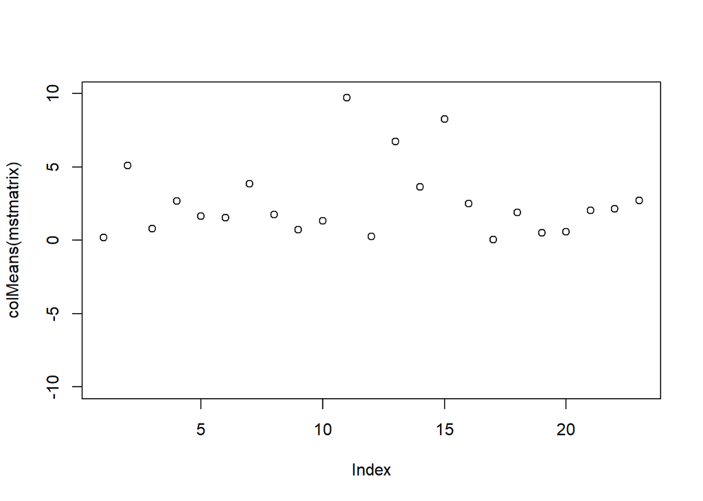

```r
#from copy/paste aggregated data from vortex
mstdata.orig <- read.csv(file = "ClusterFeatureAverages.csv")
#extract RGB values for cluster colors
vertexColors <- str_match_all(mstdata.orig$Color, "[0-9]{1,3}")
#convert to hex
vertexColors <- sapply(vertexColors, function(x)
  rgb(x[1], x[2], x[3], maxColorValue=255))

#keep only cluster IDs and feature avg values
mstdata <- mstdata.orig[,-c(1,3,4,5)]
rownames(mstdata) <- mstdata$ClusterID
mstdata$ClusterID <- NULL

for(i in c(2:ncol(mstdata))) {
  mstdata[,i] <- as.numeric(as.character(mstdata[,i]))
}

mstmatrix <- as.matrix(mstdata)
#if not clustering on all params, need to scale params not used for clustering
#all values should be near 0, very near
plot(colMeans(mstmatrix), ylim = c(-10,10))
```

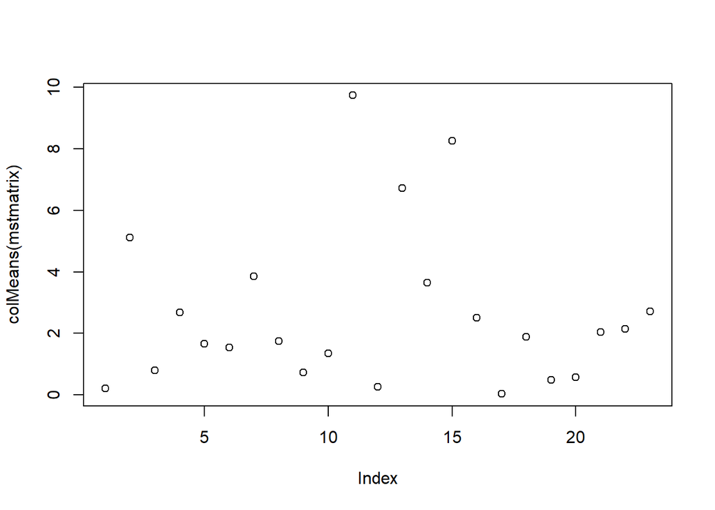

```r
#mstmatrix <- scale(mstmatrix[,c(10:27)])
plot(colMeans(mstmatrix))
```

```r
#generate distance matrix object
mydist <- dist(mstmatrix, method = 'euclidean', diag =TRUE, upper = TRUE)
#convert to matrix object
distmat <- as.matrix(mydist)
```

Plot heatmap of clusters by feature averages, can get sense of over clustering if many clusters have highly similar means across channels

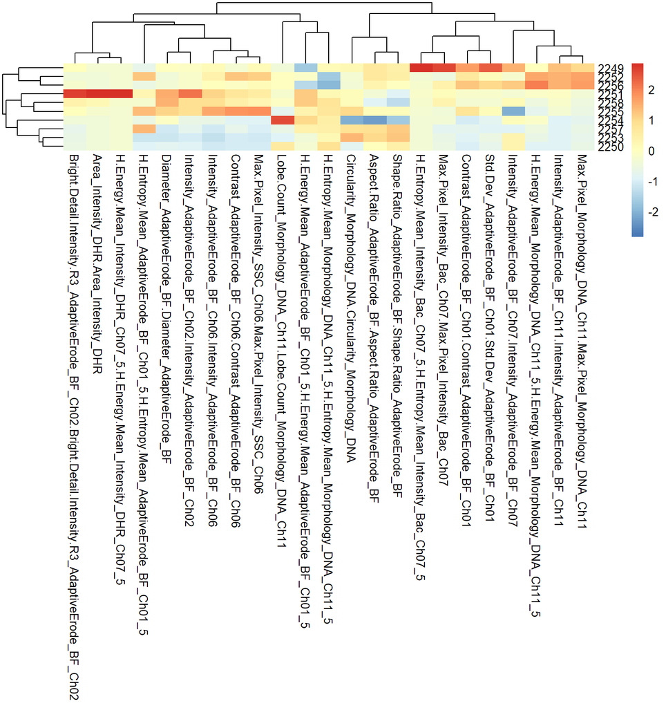

```r
pheatmap(mstdata, scale = "column")
```

Convert to igraph object and make minimum spanning tree

```r
#create adjacency matrix
g <- graph.adjacency(distmat, weighted = TRUE)
mymst <- mst(g)

V(mymst)$color <- vertexColors

list.vertex.attributes(mymst)
```

```
## [1] "name"  "color"
```

Make a layout so X/Y coords are accessible

```r
layout <- layout_with_fr(mymst, dim = 2, niter = 1000)

treecoords <- as.data.frame(layout)
rownames(treecoords) <- rownames(mstdata)
colnames(treecoords) <- c("MST-X","MST-Y")
#save this and integrate to big csv of all file events using "parse big csv" code
write.csv(treecoords, file = "MSTcoords.csv")
```

Plot MST, all nodes same size, color by cluster ID to match FDL plots

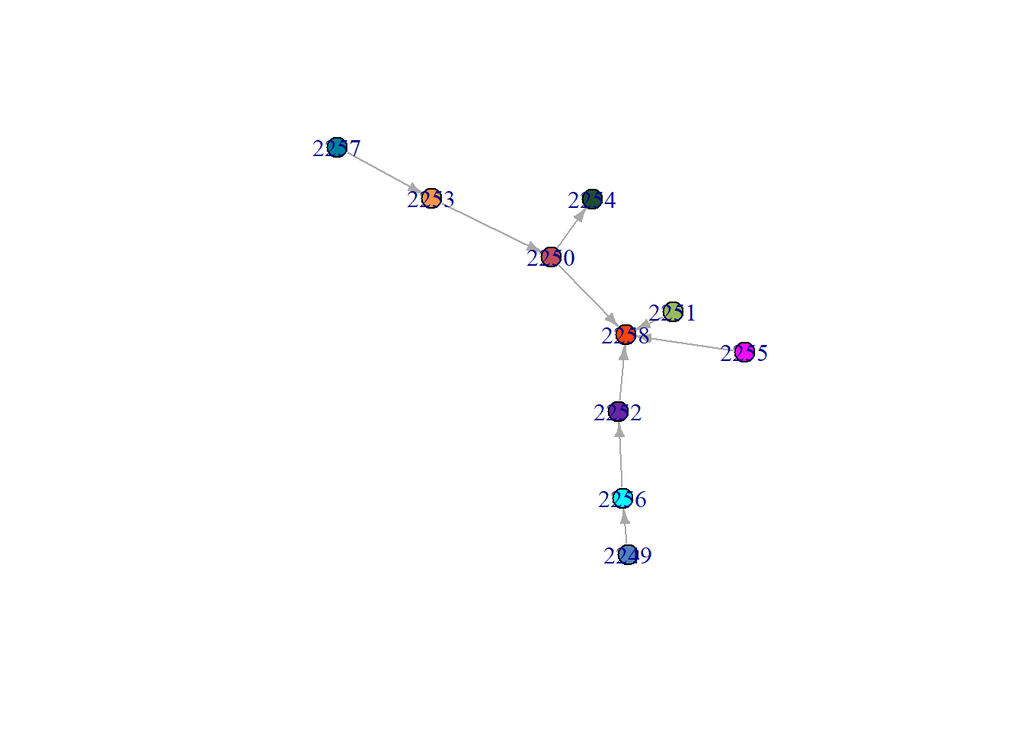

```r
plot(mymst, layout = layout, vertex.size = 10, edge.arrow.size = 0.5)
```

## Parse Big Master Csv

Accepts as input “ClusterIDs.csv”, “FDL_coords.csv” and “MSTcoords.csv”. Generates “AllData.csv” for making FDL plots in R and individual csv files for FCS Express R import

```r
#read in csv file exported from Vortex
mydata1 <- fread("ClusterIDs.csv")
#read in force directed layout coordinates
FDLdata <- fread("FDL_coords.csv", sep = ";")
colnames(FDLdata) <- c("EventID","Filename","Index_In_File","FDL-X","FDL-Y")
MSTdata <- fread("MSTcoords.csv")
colnames(MSTdata) <- c("ClusterID","MST-X","MST-Y")
MSTdata$ClusterID <- as.numeric(as.character(MSTdata$ClusterID))
FDLdata$EventID <- as.numeric(as.character(FDLdata$EventID))
#pad eventID for sorting
mydata1$EventID <- sprintf("%07d", mydata1$EventID)
#pad these too
FDLdata$EventID <- sprintf("%07d", FDLdata$EventID)

#order rows by eventID
mydata1 <- mydata1[order(mydata1$EventID),]
#order rows by eventID
FDLdata <- FDLdata[order(FDLdata$EventID),]

#remove duplicate cols with mydata1
FDLdata[,c(2,3)] <- NULL

#merge using data.table, fast!
mydata2 <- merge(mydata1, FDLdata, by = "EventID", all.x=TRUE)
mydata2 <- merge(mydata2, MSTdata, by = "ClusterID", all.x=TRUE)

mydata3 <- na.omit(mydata2, cols = "FDL-Y")

#to use for coloring graphml FDL plot by clusters
fwrite(mydata3, file = "AllData.csv")

#split big list into list of dataframes based on file name of orig files
X <- split(mydata2, mydata2$`File Name`)

#sort by original event numbers
X <- lapply(X, function(x) x[order(x$'Index in File'),])
```

Save a csv for each data frame in the list of frames

```r
lapply(1:length(X), function(i) write.csv(X[[i]],
                                          file = paste0(names(X[i]), ".csv"),
                                          row.names = FALSE))
```

## Force Directed Layout Graphs using graphml object

Takes graphml file output from vortex as input, colors using info from tabular data in “AllData.csv”

```r
#Open this, comes from "ParseBigCsv" script
FDL.all <- fread("AllData.csv")

FDL.orig <- FDL.all

#just take these cols out
FDL.all <- FDL.all[,c("ClusterID","EventID","File Name","Index in File",
                      "FDL-X","FDL-Y")]

#uses for key of clusters to colors
colorkey <- as.data.frame(V(mymst)$name)
colorkey$Color <- V(mymst)$color

colnames(colorkey) <- c("ClusterID","Color")

#convert to data table for fast merge later
colorkey <- data.table(colorkey)

colorkey$ClusterID <- factor(as.character(colorkey$ClusterID))

FDL <- read_graph(file = "FDL.graphml", format = "graphml")

#shows all vertex attributes
list.vertex.attributes(FDL)
```

```
##  [1] "label"            "r"                "g"                "b"
##  [5] "x"                "y"                "size"             "selected"
##  [9] "clusterNode"      "groupID"          "expValue"         "cluster"
## [13] "clusterZeroBased" "dpID"             "id"
```

```r
#pull out vertex list of cluster names for merging in color info
gmlclusters <- vertex_attr(FDL, "cluster")

gmlclusters <- data.table(gmlclusters)

colnames(gmlclusters) <- "ClusterID"

#factor cluster IDs
gmlclusters$ClusterID <- factor(as.character(gmlclusters$ClusterID))
#add column of numbers to use for sorting later
gmlclusters$Sort <- rownames(gmlclusters)
#transform in a numerical vector
gmlclusters$Sort <- as.numeric(as.character(gmlclusters$Sort))
#pad zeros
gmlclusters$Sort <- sprintf("%05d",gmlclusters$Sort)

#combine colorkey and gmclusters table
gmlclusters1 <- merge(gmlclusters, colorkey, by = "ClusterID", all.x = TRUE)

#reorder using sort column of numbers
gmlclusters1 <- gmlclusters1[order(Sort),]

#add color info to igraph object
V(FDL)$color <- gmlclusters1$Color

#flip Y axis values to match vortex plots
V(FDL)$y <- -1 * V(FDL)$y
```

PLot the force directed graph

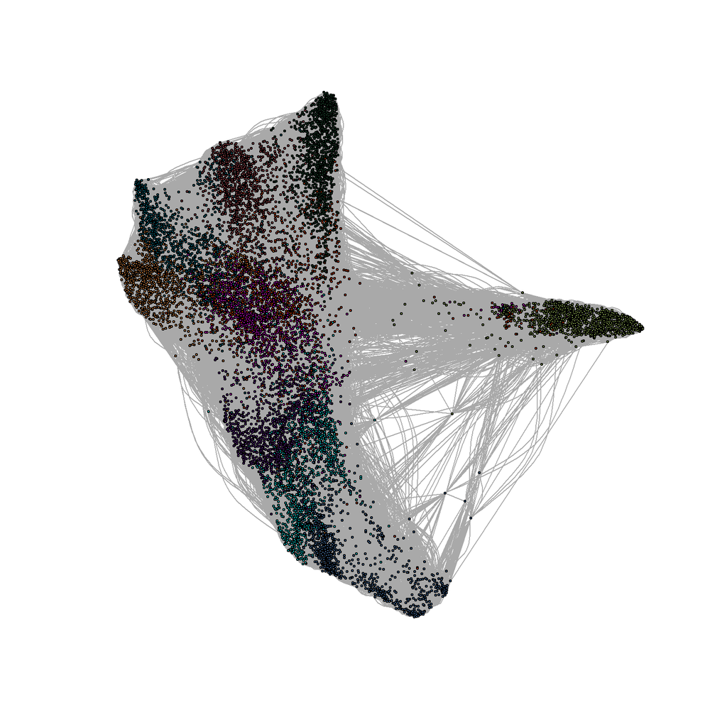

```r
plot(FDL, vertex.size = 1)
```

## Use dataframe from above section as counts table, doing this part now to make groupKey for coloring FDL plots by condition

Export the raw counts file, to use for creating an annotation data.frame

```r
#transpose it first
counts <- t(mydata)
#deal with this in excel to make group list
write.csv(counts, file="counts.csv")
```

Manipulate the “counts.csv” file in Excel as follows to create a file in the proper shape for annotations. Or, use R console if desired.

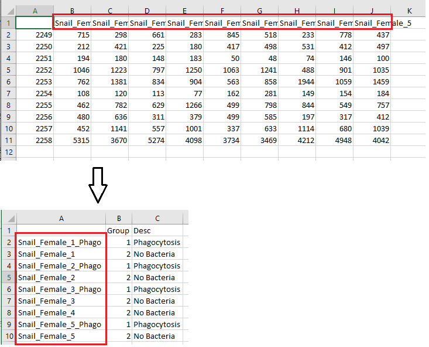

```r
#read it back in, make 1st col group numbers
groupKey <- read.csv(file = "RowLabels.csv")
#keep only groupKey rows to match files used
groupKey <- groupKey[groupKey$X %in% rownames(mydata),]
rownames(groupKey) <- groupKey$X
groupKey$X <- NULL
#refactor
groupKey$Desc <- as.character(groupKey$Desc)
groupKey$Desc <- factor(groupKey$Desc)
#factor groups
groupKey$Group <- factor(groupKey$Group)
#levels(groupKey$Group) <- c("1","2","3","4","5","6") #renumber for convenience
write.csv(groupKey, file = "groupKey.csv")
```

Setup key to color by cond

```r
#now work with this b/c has sample info that can be parsed to treatment/condition
FDL.all <- FDL.all[order(EventID),]

colnames(FDL.all) <- c("ClusterID","EventID","FileName","IndexInFile","FDL-X","FDL-Y")
FDL.all$FileName <- gsub("_processed", "", FDL.all$FileName)

#make a merge key data frame
temp1 <- groupKey
temp1$FileName <- rownames(temp1)
#remove column with group numbers
temp1[,1] <- NULL
#number row names
row.names(temp1) <- 1:nrow(temp1)
temp1 <- data.table(temp1)

#seems to be event number, data point ID?
gmlclusters2 <- as.data.frame(vertex_attr(FDL, "dpID"))
gmlclusters2$sort <- rownames(gmlclusters2)
#transform in a numerical vector
gmlclusters2$sort <- as.numeric(as.character(gmlclusters2$sort))
#pad zeros
gmlclusters2$sort <- sprintf("%05d",gmlclusters2$sort)
colnames(gmlclusters2) <- c("EventID","Sort")
gmlclusters2 <- data.table(gmlclusters2)

gmlclusters3 <- merge(FDL.all, gmlclusters2, by = "EventID", all.x = TRUE) #merge the two things
gmlclusters4 <- merge(gmlclusters3, temp1, by = "FileName")

#reorder using sort column of numbers
gmlclusters4 <- gmlclusters4[order(Sort),]


#add color info to igraph object
V(FDL)$Treatment <- as.character(gmlclusters4$Desc)

tmts <- unlist(table(V(FDL)$Treatment))

tmts1 <- c(tmts)

tmts <- names(tmts1)

rm(tmts1)

#make subgraph of only specified conditions
FDL_AmpFresh <- induced.subgraph(FDL, which(V(FDL)$Treatment=="AmpFresh"))

makeGraphs1 <- function(condName, agraph){
  x <- eval(condName)
  x <- induced.subgraph(agraph, which(V(agraph)$Treatment==condName))
  return(x)
}

graphSet1 <- lapply(tmts, FUN = makeGraphs1, FDL)

myPlotGraphs <- function(agraph){
  plot(agraph, vertex.size = 1, main = eval(levels(factor(V(agraph)$Treatment))))
}
```

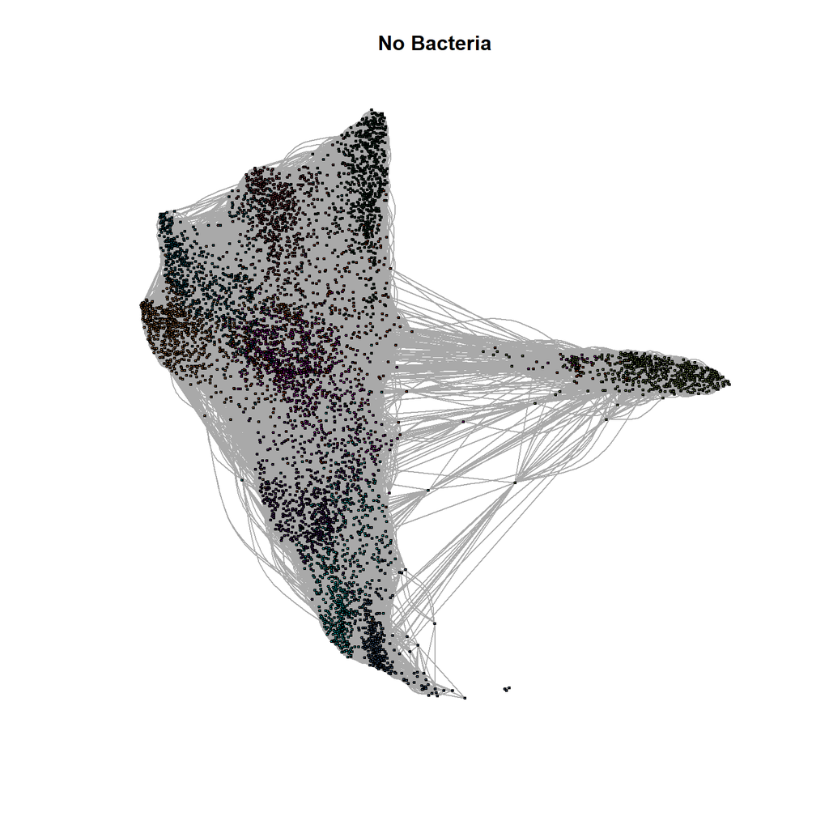

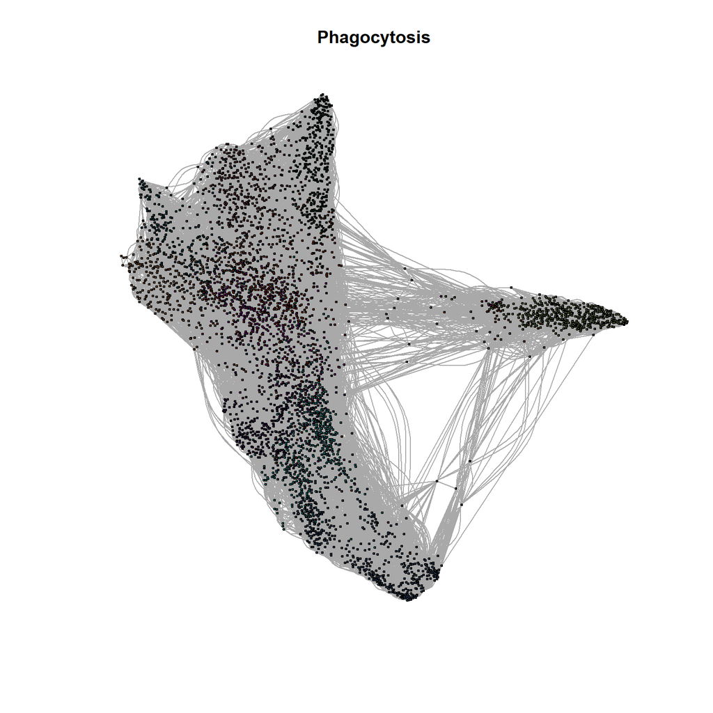

```r
lapply(graphSet1, FUN = myPlotGraphs)
```

## Use edgeR glm approach for statistical analysis, employs a negative binomial distribution model

```r
#define list of sample groups #make group list for modeling
group <- groupKey[,'Group']

## make DGElist
mylist <- DGEList(counts = counts, group = group)
write.csv(mylist$samples, file="AnnotatedSamples.csv")
dim(mylist)
```

```
## [1] 10  9
```

```r
mylist.full <- mylist
summary(cpm(mylist))
```

```
##  Snail_Female_1_Phago Snail_Female_1   Snail_Female_2_Phago Snail_Female_2
##  Min.   : 11082       Min.   : 12180   Min.   : 11834       Min.   :  8003
##  1st Qu.: 27909       1st Qu.: 33369   1st Qu.: 25814       1st Qu.: 21619
##  Median : 48328       Median : 71965   Median : 62101       Median : 66677
##  Mean   :100000       Mean   :100000   Mean   :100000       Mean   :100000
##  3rd Qu.: 76980       3rd Qu.:122056   3rd Qu.: 79904       3rd Qu.:123454
##  Max.   :545352       Max.   :372513   Max.   :552309       Max.   :425943
##  Snail_Female_3_Phago Snail_Female_3   Snail_Female_4   Snail_Female_5_Phago
##  Min.   :  6121       Min.   :  5376   Min.   :  7562   Min.   : 14682
##  1st Qu.: 43702       1st Qu.: 56333   1st Qu.: 21051   1st Qu.: 34267
##  Median : 61085       Median : 68205   Median : 52064   Median : 61796
##  Mean   :100000       Mean   :100000   Mean   :100000   Mean   :100000
##  3rd Qu.: 94810       3rd Qu.: 94412   3rd Qu.:106939   3rd Qu.: 87515
##  Max.   :457094       Max.   :388509   Max.   :430411   Max.   :497587
##  Snail_Female_5
##  Min.   : 10038
##  1st Qu.: 41985
##  Median : 62939
##  Mean   :100000
##  3rd Qu.:104196
##  Max.   :405742
```

```r
#reset libary sizes
mylist$samples$lib.size <- colSums(mylist$counts)
mylist$samples
```

```
##                      group lib.size norm.factors
## Snail_Female_1_Phago     1     9746            1
## Snail_Female_1           2     9852            1
## Snail_Female_2_Phago     1     9549            1
## Snail_Female_2           2     9621            1
## Snail_Female_3_Phago     1     8169            1
## Snail_Female_3           2     8929            1
## Snail_Female_4           2     9786            1
## Snail_Female_5_Phago     1     9944            1
## Snail_Female_5           2     9962            1
```

```r
#Normalize
mylist <- calcNormFactors(mylist, method = "none")
mylist
```

```
## An object of class "DGEList"
## $counts
##      Snail_Female_1_Phago Snail_Female_1 Snail_Female_2_Phago Snail_Female_2
## 2249                  715            298                  661            283
## 2250                  212            421                  225            180
## 2251                  194            180                  148            183
## 2252                 1046           1223                  797           1250
## 2253                  762           1381                  834            904
## 2254                  108            120                  113             77
## 2255                  462            782                  629           1266
## 2256                  480            636                  311            379
## 2257                  452           1141                  557           1001
## 2258                 5315           3670                 5274           4098
##      Snail_Female_3_Phago Snail_Female_3 Snail_Female_4 Snail_Female_5_Phago
## 2249                  845            518            233                  778
## 2250                  417            498            531                  412
## 2251                   50             48             74                  146
## 2252                 1063           1241            488                  901
## 2253                  563            858           1944                 1059
## 2254                  162            281            149                  154
## 2255                  499            798            844                  549
## 2256                  499            585            197                  317
## 2257                  337            633           1114                  680
## 2258                 3734           3469           4212                 4948
##      Snail_Female_5
## 2249            437
## 2250            497
## 2251            100
## 2252           1035
## 2253           1459
## 2254            184
## 2255            757
## 2256            412
## 2257           1039
## 2258           4042
##
## $samples
##                      group lib.size norm.factors
## Snail_Female_1_Phago     1     9746            1
## Snail_Female_1           2     9852            1
## Snail_Female_2_Phago     1     9549            1
## Snail_Female_2           2     9621            1
## Snail_Female_3_Phago     1     8169            1
## Snail_Female_3           2     8929            1
## Snail_Female_4           2     9786            1
## Snail_Female_5_Phago     1     9944            1
## Snail_Female_5           2     9962            1
```

*must specify # of analysis groups for the “numGrps” variable below*

Maximum 9 unless you change from “Set1” to another such as “Set3”

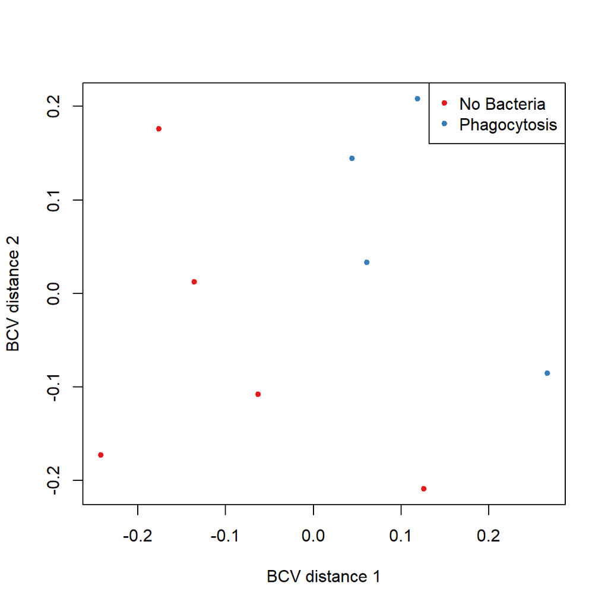

```r
numGrps <- 2
mycolors <- brewer.pal(9, "Set1")
jColors <- with(groupKey,
                data.frame(Desc = levels(Desc),
                      color = mycolors[1:numGrps]))


plotMDS(mylist, method="bcv",
        col = jColors$color[match(groupKey$Desc, jColors$Desc)],
        pch=20)
legend("topright", levels(groupKey$Desc),
       col=jColors$color, pch=20)
```

## glm method

```r
#define exp design
design1 <- model.matrix(~ 0 + group, data=mylist$samples)
#esimate common dispersion
y <- estimateDisp(mylist, design1)
```

Plot Biological CVs

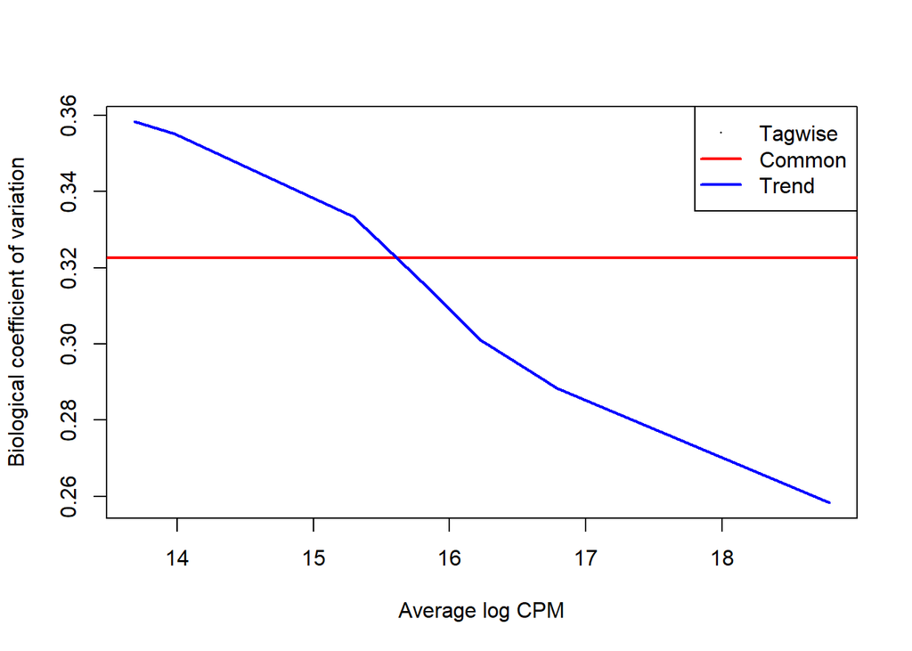

```r
plotBCV(y)
```

Fit the model and run a contrast between groups to obtain statistics output

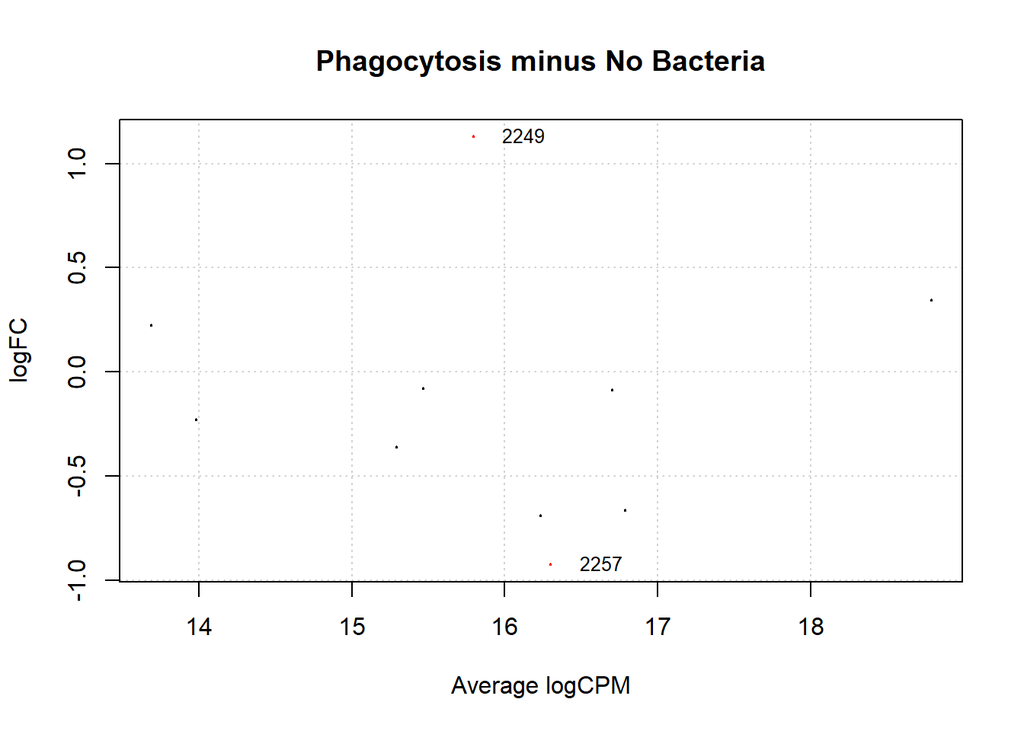

```r
#groups EDTA control vs Phagocytosis
fit <- glmFit(y, design1) #fit model using design matrix

lrt.one <- glmLRT(fit, contrast = c(1,-1))
DEG1 <- topTags(lrt.one, n=20, p.value = 0.05)
write.csv(DEG1, file = "PhagoMinusIce.csv")

plotSmear(lrt.one, de.tags = rownames(DEG1$table), main = "Phagocytosis minus No Bacteria")
text(x = DEG1$table$logCPM,
     y = DEG1$table$logFC,
     labels=rownames(DEG1$table),
     cex = 0.8,
     pos = 4,
     offset = 1)
```

Below you can see an example of contrasting when there are 4 groups, this chunk is not running in this document however as the example files are from the same group and non clusters can be pulled out by this method as files are too similar.

```r
fit <- glmFit(y, design1) #fit model using design matrix
#groups Phago Minus Ice
lrt.one <- glmLRT(fit, contrast = c(-1,1,0,1))
DEG1 <- topTags(lrt.one, n=20, p.value = 0.05)

#groups Phago Minus EDTA
lrt.two <- glmLRT(fit, contrast = c(-1,0,0,1))
DEG2 <- topTags(lrt.two, n=20, p.value = 0.05)

#groups Phago Minus NoBact
lrt.three <- glmLRT(fit, contrast = c(0,0,-1,1))
DEG3 <- topTags(lrt.three, n=20, p.value = 0.05)

write.csv(DEG1, file = "PhagoMinusIce.csv")
write.csv(DEG2, file = "PhagoMinusEDTA.csv")
write.csv(DEG3, file = "PhagoMinusNoBact.csv")

plotSmear(lrt.one, de.tags = rownames(DEG1$table), main = "Phago Minus Ice")
text(x = DEG1$table$logCPM,
     y = DEG1$table$logFC,
     labels=rownames(DEG1$table),
     cex = 0.8,
     pos = 4,
     offset = 1)

plotSmear(lrt.two, de.tags = rownames(DEG2$table), main = "Phago Minus EDTA")
text(x = DEG2$table$logCPM,
     y = DEG2$table$logFC,
     labels=rownames(DEG2$table),
     cex = 0.8,
     pos = 4,
     offset = 1)

plotSmear(lrt.three, de.tags = rownames(DEG3$table), main = "Phago Minus NoBact")
text(x = DEG3$table$logCPM,
     y = DEG3$table$logFC + 6,
     labels=rownames(DEG3$table),
     cex = 0.8,
     pos = 4,
     offset = 1)

#Also want to do correlation and throw out outliers
rowAnnot <- as.data.frame(groupKey$Desc)
rownames(rowAnnot) <- rownames(mydata)
#rowAnnot$Group <- NULL

pdf(file = "HeatmapSamplesByClusterCounts.pdf", width = 8, height = 6, onefile = FALSE)
pheatmap(log(mydata+1), scale = "column", annotation_row = rowAnnot)
dev.off()
graphics.off()

pdf(file = "CorrelationSamplesByClusterCounts.pdf", width = 10, height = 10, onefile = FALSE)
pheatmap(cor(counts), annotation_row = rowAnnot)
dev.off()
graphics.off()
```

## Plot MST with vertices sized proportional to counts per cluster

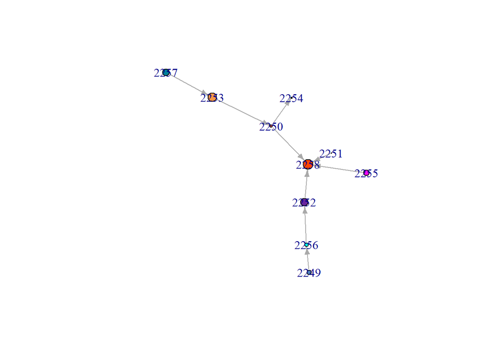

```r
ClusterCounts <- as.data.frame(colSums(mydata))
colnames(ClusterCounts) <- "TotalCounts"
ClusterCounts$ClusterID <- rownames(ClusterCounts)
rownames(ClusterCounts) <- 1:nrow(ClusterCounts)
vertexatt <- merge(ClusterCounts, colorkey, by = "ClusterID")
vertexatt1 <- as.data.frame(V(mymst)$name)
colnames(vertexatt1) <- "ClusterID"
vertexatt1$Sort <- rownames(vertexatt1)
#as numeric
vertexatt1$Sort <- as.numeric(as.character(vertexatt1$Sort))
#pad zeros
vertexatt1$Sort <- sprintf("%05d",vertexatt1$Sort)
vertexatt1 <- data.table(vertexatt1)
vertexatt <- data.table(vertexatt)
vertexatt <- merge(vertexatt, vertexatt1, by = "ClusterID")
vertexatt <- vertexatt[order(Sort),]

#calculate CDF for cluster counts distribution
scaledvert <- ecdf(vertexatt$TotalCounts)

#apply to cluster counts and scale to size nodes of graph
V(mymst)$size <- scaledvert(vertexatt$TotalCounts) * 10

#put into dataframe just to have it
vertexatt$CumDist <- scaledvert(vertexatt$TotalCounts)

#plot new MST, node sizes proportional to counts, nodes color to match FDL plots

#specifying layout here determines coordinates
plot(mymst, layout = layout,
     edge.arrow.size = 0.5,
     label.dist = 1,
     vertex.color = vertexColors)
```